Skip to content

[Download this tutorial](https://raw.githubusercontent.com/DSichang/scMultiBench/main/notebooks/tutorial_vertical_rna_atac.ipynb)

# Vertical integration: RNA + ATAC

Vertical integration combines modalities measured in the same cells. This tutorial is for RNA and ATAC, as in 10x Multiome. It runs scMM and VIMCCA on `D27mini_vertical`, 5,000 cells of the benchmark dataset `D27`, and then on data in your own format.

Methods run on Linux. scMM has no Windows environment, and scMM and VIMCCA have no macOS environment. On Windows or macOS, [open this notebook in Colab](https://colab.research.google.com/github/DSichang/scMultiBench/blob/main/notebooks/tutorial_vertical_rna_atac.ipynb): sections 1 to 4 take about 11 minutes there.

## 1. Install

pip may then print a note about restarting the kernel: no restart is needed, because the pins keep the numpy and pandas already installed.

```python
import numpy, pandas
pins = f"numpy=={numpy.__version__} pandas=={pandas.__version__}"
%pip install -q "multibench-sc>=0.7.4" {pins}
```

import numpy, pandas pins = f"numpy=={numpy.__version__} pandas=={pandas.__version__}" %pip install -q "multibench-sc>=0.7.4" {pins}

## 2. Download the data and the environments

`mtb.data.fetch` downloads `D27mini_vertical` (24 MB) once. `mtb.env.install` downloads the environments for scMM and VIMCCA. The download is 1.2 GB.

```python
import multibench as mtb

mtb.data.fetch("D27mini_vertical")
METHODS = ["scMM", "VIMCCA"]
envs = mtb.env.install(METHODS)
```

import multibench as mtb mtb.data.fetch("D27mini_vertical") METHODS = ["scMM", "VIMCCA"] envs = mtb.env.install(METHODS)

```
downloading D27mini_vertical (24 MB) ...
[env] downloading scmb_vimcca 725 MB ...
[env]   725 MB of 725 MB (29 MB/s)
[env] unpacking scmb_vimcca ...
```

## 3. Run the methods

`run` runs each method on `D27mini_vertical` and scores its output with the [scIB metrics](https://dsichang.github.io/scMultiBench/tutorials/evaluate/#what-each-metric-measures). The clustering metrics score how well the embedding's clusters and neighbourhoods match the cell types, and how separate the clusters are. Higher is better for every metric.

**Details**

`params={"Method": {"key": value}}` sets a method's parameters, and `mtb.params_for` lists them.

`mtb.load_run("out/D27mini_vertical")` reloads these results later.

```python
res = mtb.run("D27mini_vertical", "vertical", methods=METHODS,
              out_dir="out/D27mini_vertical")
res.summary
```

res = mtb.run("D27mini_vertical", "vertical", methods=METHODS, out_dir="out/D27mini_vertical") res.summary

```
[run] VIMCCA (vertical/D27mini_vertical) ...
[run]   -> scored (18.4s) ARI 0.388
[run] scMM (vertical/D27mini_vertical) ...
[run]   -> scored (55.1s) ARI 0.276
```

|  | method | status | ARI | NMI | ASW | iASW | iF1 | cLISI | run_sec | caveat | reason |
| --- | --- | --- | --- | --- | --- | --- | --- | --- | --- | --- | --- |
| 0 | VIMCCA | scored | 0.3879 | 0.5710 | 0.6248 | 0.6217 | 0.523 | 0.9607 | 18.4 |  |  |
| 1 | scMM | scored | 0.2762 | 0.4837 | 0.6001 | 0.6045 | 0.389 | 0.8963 | 55.1 |  |  |

## 4. Plot

`res.plot()` draws the scores as a bubble table. Circle size ranks the rows within each column and colour shows the value scaled per column, so a small gap can look large. `res.summary` has the values.

**Details**

Metrics are grouped by family: blue for clustering. Each family starts with an `Overall` bar: each row's mean rank over the family's metrics, scaled so that the lowest gets the shortest bar.

A column with fewer than two different values is drawn grey. A figure of one method is grey everywhere.

```python
res.plot()
```

res.plot()

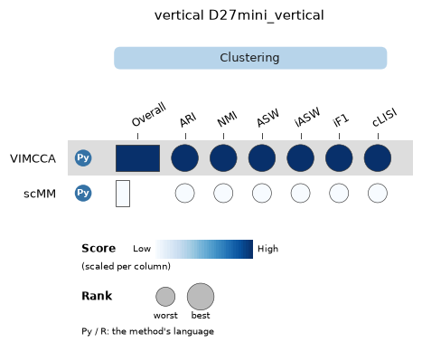

## 5. Your own data

Your data needs raw RNA counts, an ATAC matrix of the same cells and a cell type for each cell, as two `.h5ad` files.

Recipes cover [a 10x `.h5` file](https://dsichang.github.io/scMultiBench/tutorials/run/#recipe-10x-h5), [labels in a CSV file](https://dsichang.github.io/scMultiBench/tutorials/run/#recipe-labels-csv), [no labels](https://dsichang.github.io/scMultiBench/tutorials/run/#recipe-no-labels) and [several donors or samples](https://dsichang.github.io/scMultiBench/tutorials/run/#recipe-donors).

**Details: export**

A 10x Multiome MuData goes in with one call. Here the labels are in `mdata.obs`. For labels in `mdata["rna"].obs`, write `labels="rna:celltype"`.

```
mtb.io.export_dataset(mdata, "mydata/" + NAME, rna="rna", atac="atac",
                      atac_kind="peak", labels="obs:celltype",
                      category="vertical")
```

The next cell writes two small example files, `my_rna.h5ad` and `my_atac.h5ad`, from 60% of the cells of `D27mini_vertical`. Skip it for your own data.

```python
mtb.data.write_example("D27mini_vertical")
```

mtb.data.write_example("D27mini_vertical")

```
wrote my_rna.h5ad: 3,000 cells. RNA counts in X, cell types in obs["celltype"].
wrote my_atac.h5ad: 3,000 cells. ATAC peak counts in X, cell types in obs["celltype"].
```

Read your files. For your own data, change every file name marked `# <-`. On Colab, upload the files first: click the folder icon on the left, then the upload icon.

```python
import anndata as ad

rna = ad.read_h5ad("my_rna.h5ad")     # <- your RNA file
atac = ad.read_h5ad("my_atac.h5ad")   # <- your ATAC file, the same cells
print(rna)
print(atac)
```

import anndata as ad rna = ad.read_h5ad("my_rna.h5ad") # <- your RNA file atac = ad.read_h5ad("my_atac.h5ad") # <- your ATAC file, the same cells print(rna) print(atac)

```
AnnData object with n_obs × n_vars = 3000 × 2500
    obs: 'celltype'
    layers: None (.X)
AnnData object with n_obs × n_vars = 3000 × 5000
    obs: 'celltype'
    layers: None (.X)
```

Write the dataset folder. Change each name in quotes marked `# <-` to one the printout above lists for your files, with its prefix, as `"obs:celltype"`.

```python
NAME = "MYMULTIOME"   # <- a new name for your own data
mtb.io.export_dataset(rna, "mydata/" + NAME,
                      rna="X",                # <- where the RNA counts are:
                                              #    "X" or "layer:counts"
                      atac=atac,              # the ATAC file, peak counts in X
                      atac_kind="peak",       # the methods here read peaks
                      labels="obs:celltype",  # <- the cell-type column
                      overwrite=True)
mtb.scan("mydata/" + NAME, "vertical", methods=METHODS)
```

NAME = "MYMULTIOME" # <- a new name for your own data mtb.io.export_dataset(rna, "mydata/" + NAME, rna="X", # <- where the RNA counts are: # "X" or "layer:counts" atac=atac, # the ATAC file, peak counts in X atac_kind="peak", # the methods here read peaks labels="obs:celltype", # <- the cell-type column overwrite=True) mtb.scan("mydata/" + NAME, "vertical", methods=METHODS)

```
[scan] 2 of 2 methods have their input files in MYMULTIOME. 2 of 2 can run on this computer. MYMULTIOME holds RNA and ATAC.
[scan] Cells per file: rna.h5 3,000, atac.h5 3,000, atac_peak.h5 3,000.
```

|  | method | modalities | runnable | reason | env | caveat |
| --- | --- | --- | --- | --- | --- | --- |
| 0 | VIMCCA | rna+atac | True |  | scmb_vimcca |  |
| 1 | scMM | rna+atac | True |  | scmb_scmm2 | scMM reads inputs/rna.h5, inputs/atac.h5. mtb.... |

```python
mine = mtb.run("mydata/" + NAME, "vertical", methods=METHODS,
               out_dir="out/" + NAME)
mine.summary
```

mine = mtb.run("mydata/" + NAME, "vertical", methods=METHODS, out_dir="out/" + NAME) mine.summary

```
[run] VIMCCA (vertical/MYMULTIOME) ...
[run]   -> scored (13.1s) ARI 0.373
[run] scMM (vertical/MYMULTIOME) ...
[run]   -> scored (35.5s) ARI 0.317
```

|  | method | status | ARI | NMI | ASW | iASW | iF1 | cLISI | run_sec | caveat | reason |
| --- | --- | --- | --- | --- | --- | --- | --- | --- | --- | --- | --- |
| 0 | VIMCCA | scored | 0.3726 | 0.5684 | 0.6130 | 0.6259 | 0.5044 | 0.9515 | 13.1 |  |  |
| 1 | scMM | scored | 0.3171 | 0.4731 | 0.5729 | 0.5806 | 0.3867 | 0.8883 | 35.5 |  |  |

```python
mine.plot()
```

mine.plot()

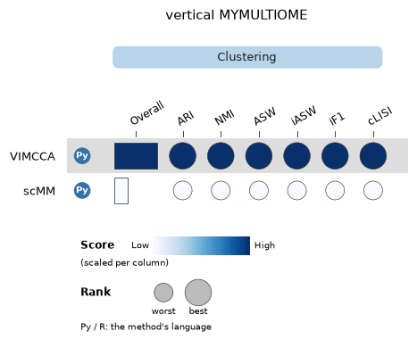

## 6. Every method of this task

14 methods run this task. [This notebook](https://colab.research.google.com/github/DSichang/scMultiBench/blob/main/notebooks/tutorial_vertical_rna_atac_all.ipynb) runs them all. Its 13 environments download 31.8 GB on a computer without a GPU and 37.6 GB on one with a GPU.

## Troubleshooting

`res.summary[res.summary.status != "scored"]` lists each method that failed or was skipped. Its `reason` column ends with the method's error output.

**Details**

| symptom | fix |
| --- | --- |
| a method fails on a small dataset | `mtb.scan` names what the method needs from the data's size in its `caveat` column |

## Next steps

- [Run a method](https://dsichang.github.io/scMultiBench/tutorials/run/), [Score an embedding](https://dsichang.github.io/scMultiBench/tutorials/evaluate/), [Load and plot results](https://dsichang.github.io/scMultiBench/tutorials/plot/) and [Discover methods](https://dsichang.github.io/scMultiBench/tutorials/discover/).
- [Look at an embedding](https://dsichang.github.io/scMultiBench/tutorials/evaluate/#look-at-an-embedding) draws a method's embedding as a UMAP.
- The [interactive explorer](https://shiny.maths.usyd.edu.au/scMultiBench/) has the full benchmark's rankings, with no install needed.